# ejercicio_unidad_1

Samuel Melo Balcázar

2025-02-17

# *Introducción*

En el presente análisis se analizan los datos obtenidos de un dataset que corresponde a las ventas realizadas en algunos centros comerciales en Estambul. En este se puede encontrar, como se ve más adelante, datos correspondientes a los clientes, productos, factuas, centros comerciales, entre otros.

En este ejercicio se han puesto en práctica los conceptos y técnicas aprendidos a lo largo de la unidad, con los cuales se pudo realizar un EDA en R y se ha podido analizar el conjunto de datos proporcionado.

# *Paso 1:* Creación de tabla descriptiva

A continuación, se crea una tabla descriptiva que contiene las variables: nombre de las variables, la descripción de la misma, su clafisicación según la naturaleza y el origen de cada una. Esta tabla contiene las variables del set de datos seleccionados para el presente ejercicio.

| variables | variable_descriptions | nature | origin |
| --- | --- | --- | --- |
| invoice_no | Numero de factura | NA | variable determinística |
| customer_id | id de cliente | NA | variable determinística |
| gender | Sexo de clientes | cualitativa \| escala nominal | variable aleatoria |
| age | Edad | cuantitativa \| escala de razón | variable aleatoria |
| category | Articulo comprado | cualitativa \| escala nominal | variable aleatoria |
| quantity | Cantidad | cuantitativa \| escala de razón | variable aleatoria |
| price | Precio | cuantitativa \| escala de razón | variable aleatoria |
| payment_method | Metodo de pago | cualirariva \| escala nominal | variable aleatoria |
| invoice_date | Fecha de factura | NA | variable aleatoria |
| shopping_mall | nombre del mall | cualitativa \| escala nominal | variable aleatoria |

# *Paso 2*: Identificación y eliminación de duplicados

En este paso se identifican los datos duplicados en el dataset y se elimanan.

```
La dimensión de la data original es de: 99466 registros
```

```
La dimensión de la data sin duplicados es de: 99457 registros
```

| invoice_no | customer_id | gender | age | category | quantity | price | payment_method | invoice_date | shopping_mall |
| --- | --- | --- | --- | --- | --- | --- | --- | --- | --- |
| I317333 | C111565 | Male | 21 | Shoes | 3 | 180051 | Debit Card | 2021-12-12 | Forum Istanbul |
| I294687 | C300786 | Male | 65 | Books | 2 | NA | Debit Card | 2021-01-16 | Metrocity |
| I337719 | C320928 | Male | 40 | Cosmetics | 5 | 2033 | Cash | 2021-01-18 | Istinye Park |
| I258204 | C167183 | Female | 54 | Clothing | 1 | 30008 | Credit Card | 2023-02-03 | Emaar Square Mall |
| I184085 | C175610 | Female | 33 | Cosmetics | 3 | 12198 | Credit Card | 2021-12-11 | Mall of Istanbul |

En la tabla anterior se evidencian los registros que están duplicados.

# *Paso 3*: Detección de valores atípicos o inconsistencias

Para conocer los valores atípicos en el dataset usado en el presente informe se realiza el siguiente proceso: primero, se escogen las variable cuantitativas; segundo se generan gráficos de caja individiuales para determinar cuáles de estas tienen valores atípicos.

Los resultados de esto se muestran a continuación.

```
      age           quantity         price
 Min.   :18.00   Min.   :1.000   Min.   :      1
 1st Qu.:30.00   1st Qu.:2.000   1st Qu.:   2615
 Median :43.00   Median :3.000   Median :  12198
 Mean   :43.43   Mean   :3.003   Mean   :  42925
 3rd Qu.:56.00   3rd Qu.:4.000   3rd Qu.:  60016
 Max.   :69.00   Max.   :5.000   Max.   :7575000
 NA's   :19                      NA's   :22
```

```
[1] "Bloxplot de edad, cantidad y precio"
```

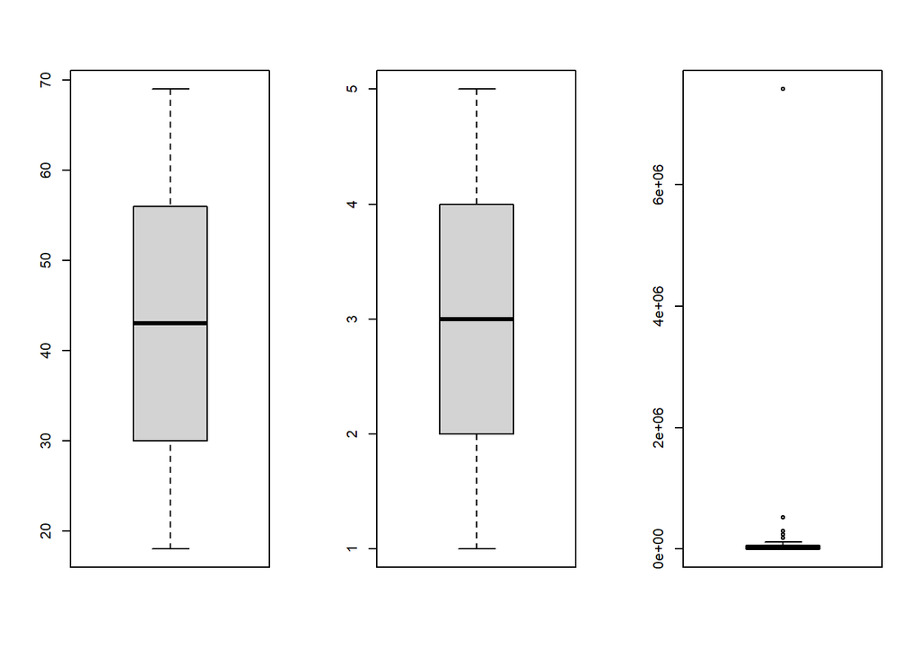

A continuación, se explica el manejo de los datos atípicos.

# *Paso 4*: Manejo de valores atípicos

Tomar decisiones sobre cómo tratar los valores atípicos o inconsistentes. Documentar las razones de las decisiones adoptadas y presentar una tabla comparativa con los datos antes y después del tratamiento. Incluir gráficos que ilustren el impacto de las decisiones tomadas, junto con indicadores descriptivos actualizados.

Ya que el dataset presenta datos atípicos, el paso que se decide tomar es eliminarlos, dado que generan distorsión y dificultan el análisis de los datos presentados.

Una inquietud que surge en este proceso es la del peso porcentual de los datos atípicos. Para ello, se realizó la siguiente la variable “atipico”, en la que 1 significa atípico -que está por encima del límite superior-, y 0, que no. Con esta información, se puede determinar que los datos que están por fuera del ls son cerca del 6 % del dataset.

```
                  0 0.00100545964587711
              93389                6046
```

```
 3rd Qu.
146117.5
```

```
 1st Qu.
-83486.5
```

```
3rd Qu.
  60016
```

Los datos se eliminan por protocolo, dadas las razones ya expuestas.

```
[1] "Tabla de resumen de edad, precio y cantidad"
```

```
Descriptive Statistics
df_a
N: 6046

                        age   atipico        price   quantity
----------------- --------- --------- ------------ ----------
             Mean     43.21      1.00    241367.69       4.00
          Std.Dev     15.04      0.00    106340.33       0.82
              Min     18.00      1.00    180051.00       1.00
               Q1     30.00      1.00    180051.00       3.00
           Median     43.00      1.00    240068.00       4.00
               Q3     56.00      1.00    300085.00       5.00
              Max     69.00      1.00   7575000.00       5.00
              MAD     19.27      0.00     88981.20       1.48
              IQR     26.00      0.00    120034.00       2.00
               CV      0.35      0.00         0.44       0.20
         Skewness      0.03       NaN        54.24      -0.01
      SE.Skewness      0.03      0.03         0.03       0.03
         Kurtosis     -1.20       NaN      3738.32      -1.47
          N.Valid   6046.00   6046.00      6046.00    6046.00
        Pct.Valid    100.00    100.00       100.00     100.00
```

Ahora bien, dentro de las variables cuantitativas se puede observar que, al igual que ilustra el boxplot, no hay presencia de datos muy grandes en age ni quantity. Lo anterior demuestra que se deben centrar las acciones en la variable price.

```
[1] "Resumen de atípicos de precio"
```

```
   Min. 1st Qu.  Median    Mean 3rd Qu.    Max.
 180051  180051  240068  241368  300085 7575000
```

En la tabla anterior se pueden notar los valores máximos y mínimos de la variable “price”, que es la de interés en este momento. Así, se puede observar el valor más alto, que es de más de siete millones. Con esta información se puede puede realizar el boxplot con los datos atípicos.

En este sentido, se pueden observar los datos atípicos el el siguiente gráfico.

```
[1] "Boxplot de datos atípicos de precios"
```

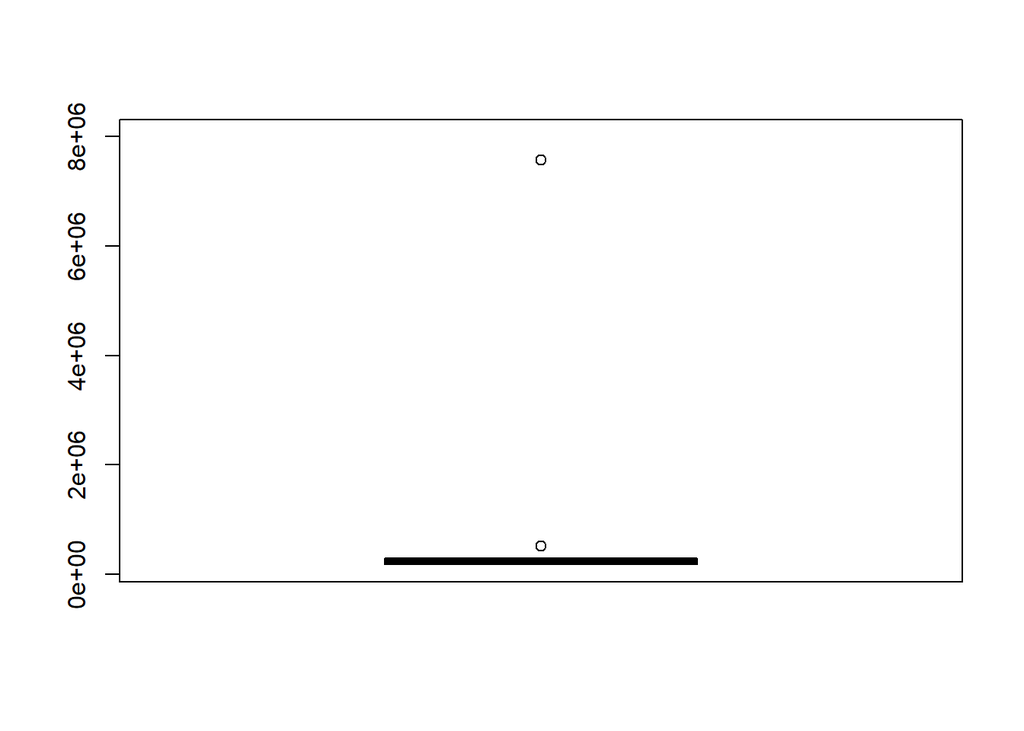

```
[1] "Gráfico de precios sin atípicos"
```

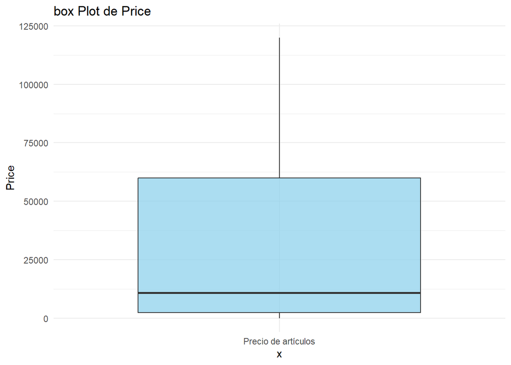

Una vez excluídos los datos atípicos, se puede observar en este boxplot datros entre 2000 y 60 000 liras. Estos valores son los cuartiles, inferior y superior, respectivamente. Este gráfico muestra la concentración de los valores alrededor de la mediana.

Como se ha excluído los valores atípicos, se facilita exhibir y analizar los datos, como estos mínimos y máximos, como tendencias y patrones representativos.

# *Paso 5*: Análisis de datos faltantes

El análisis de los datos faltantes se realiza con el set de datos sin los datos duplicados. Para realizarlo, se seleccionan las variables, sin tener en cuenta las de identificación de clientes ni facturas, puesto que estas no son interesantes para el presente trabajo. Por ende, las variables seleccionadas son: género, edad, categoría, cantidad, precio y método de pago.

Calcular el porcentaje de datos faltantes por variable. Presentar los resultados mediante al menos dos gráficos que destaquen las variables afectadas y el porcentaje de datos faltantes correspondiente.

```
[1] "Resumen de categorías sin datos duplicados"
```

|  | gender | age | category | quantity | price | payment_method |
| --- | --- | --- | --- | --- | --- | --- |
|  | Length:99457 | Min. :18.00 | Length:99457 | Min. :1.000 | Min. : 1 | Length:99457 |
|  | Class :character | 1st Qu.:30.00 | Class :character | 1st Qu.:2.000 | 1st Qu.: 2615 | Class :character |
|  | Mode :character | Median :43.00 | Mode :character | Median :3.000 | Median : 12198 | Mode :character |
|  | NA | Mean :43.43 | NA | Mean :3.003 | Mean : 42925 | NA |
|  | NA | 3rd Qu.:56.00 | NA | 3rd Qu.:4.000 | 3rd Qu.: 60016 | NA |
|  | NA | Max. :69.00 | NA | Max. :5.000 | Max. :7575000 | NA |
|  | NA | NA’s :19 | NA | NA | NA’s :22 | NA |

El listado anterior muestra que el total de registros en las variables es el número de la dimensión del data set, es decir, corresponde a todos los registros. Sin embargo, hay algunas variables que poseen datos faltantes, y que son del interés del presente análisis.

Tal como se muestra a continuación, esta nueva tabla expone de mejor manera el total de datos faltantes en cada variable. Ahora bien, las variables que se escogerán, según sea mejor en el siguiente paso, son las cuantitativas, concretamente edad.

```
[1] "Tabla de datos faltantes por variable"
```

|  | faltantes |
| --- | --- |
| gender | 19 |
| age | 19 |
| shopping_mall | 10 |
| category | 8 |
| payment_method | 8 |
| invoice_no | 0 |
| customer_id | 0 |
| quantity | 0 |
| price | 0 |
| invoice_date | 0 |
| atipico | 0 |

# *Paso 6*: Test de hipótesis para datos faltantes

Se plantea una hipótesis nula (Ho) y una alternativa (Ha). La primera, hace referencia a que los datos faltantes son MCAR, es decir, randoms, ocurren por completo al azar; la segunda, quiere decir que no son randoms, que hay un patrón entre estos y que puede depender de otras variables.

Se realiza el test de hipótesis, el cual tiene el siguiente resultado.

```
[1] "Test de hipótesis"
```

```
# A tibble: 1 × 4
  statistic    df p.value missing.patterns
      <dbl> <dbl>   <dbl>            <int>
1      51.7    62   0.823                8
```

El resultado del test de hipótesis fue 0.822762, lo que significa que no hay evidencia suficiente para negar la Ho, por lo que los datos faltantes carecen de una relación o patrón. Esto quiere decir que se pueden omitir o imputar sin temor a que se modifique significativamente el conjunto de datos. En conclusión, se pueden tomar las decisiones previamente mencionadas sin temor a sesgar el ejercicio.

# *Paso 7*: Imputación de datos faltantes

Según lo anterior, se toma la decición de imputar por la media de la variable. Esta decisión se toma por dos motivos. El primero, el resultado anterior evidencia la carencia de patrón y demuestra la aleatoriedad en los datos faltantes, por lo que la acción aquí tomada no tiene efecto significativo en el conjunto de datos; la segunda, se puede considerar como lo más correcto metodológicamente hablando (Muñoz y Álvarez, 2009), ya que es más eficaz para este tipo de casos y se cuenta con usa más información disponible.

Esta decisión se toma a pesar de que estos datos no poseen mayor peso porcentual e impacto en el dataset. Sin embargo, dado el test de hipótesis se quiere contar con la mayor cantidad de datos, teniendo en cuenta que no altera significativamente los resultados del ejercicio.

```
[1] "Datos perdidos por variables"
```

```
La media de la edad es: 43
```

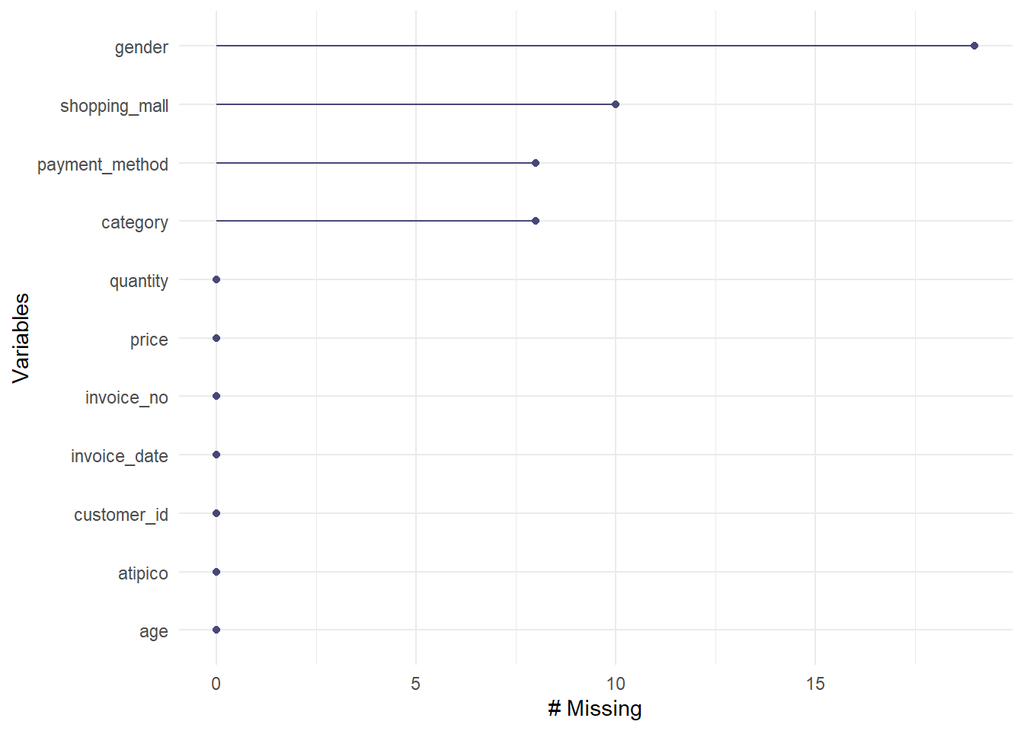

En esta imputación se reemplazaron los datos faltantes de la variable edad, que es la que interesa para el presente análisis, con la media de la misma. Como resultado de esto, se puede evidenciar en el gráfico anterior que esta característica en el *dataset* no presenta datos faltantes.

```
[1] "Tabla de resumen de variables sin atípicos ni duplicados"
```

|  | gender | age | category | quantity | price | payment_method |
| --- | --- | --- | --- | --- | --- | --- |
|  | Length:93389 | Min. :18.00 | Length:93389 | Min. :1.000 | Min. : 1 | Length:93389 |
|  | Class :character | 1st Qu.:30.00 | Class :character | 1st Qu.:2.000 | 1st Qu.: 2346 | Class :character |
|  | Mode :character | Median :43.00 | Mode :character | Median :3.000 | Median : 10752 | Mode :character |
|  | NA | Mean :43.44 | NA | Mean :2.939 | Mean : 30078 | NA |
|  | NA | 3rd Qu.:56.00 | NA | 3rd Qu.:4.000 | 3rd Qu.: 60016 | NA |
|  | NA | Max. :69.00 | NA | Max. :5.000 | Max. :120034 | NA |

# *Paso 8*: Análisis descriptivo post-procesamiento

Una vez efectuado el posprocesado de los datos, se visualizan las siguientes variables.

En primer lugar, se puede observar la distribución por género de las y los clientes. Esta clasificación es binaria, puesto que abarca hombres y mujeres.

En este orden de ideas, se puede observar que las compras fueron, en el total, hechas por mujeres, puesto que seis de cada diez compras fueron hechas por mujeres. Con esta información se pueden elaborar distintas estrategias para atraer a este segmento poblacional.

```
[1] "Gráfico de clientes por sexo"
```

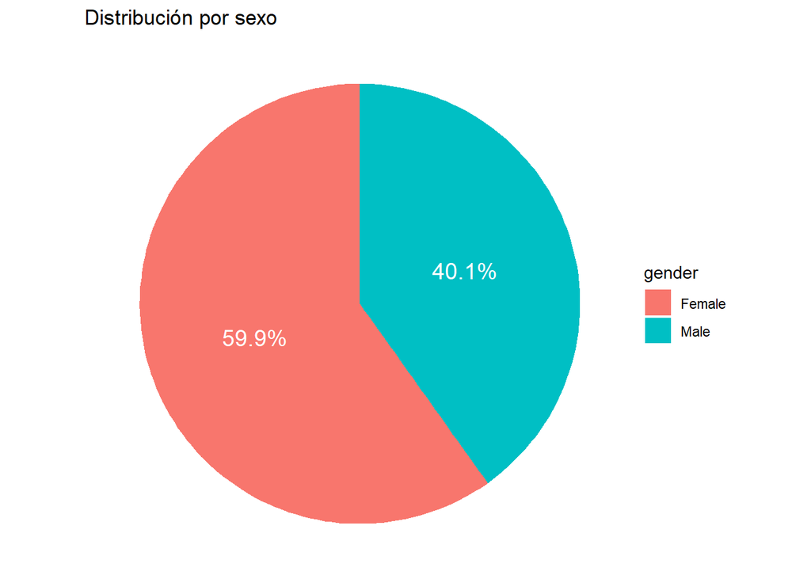

```
[1] "Gráfico de edades de los clientes"
```

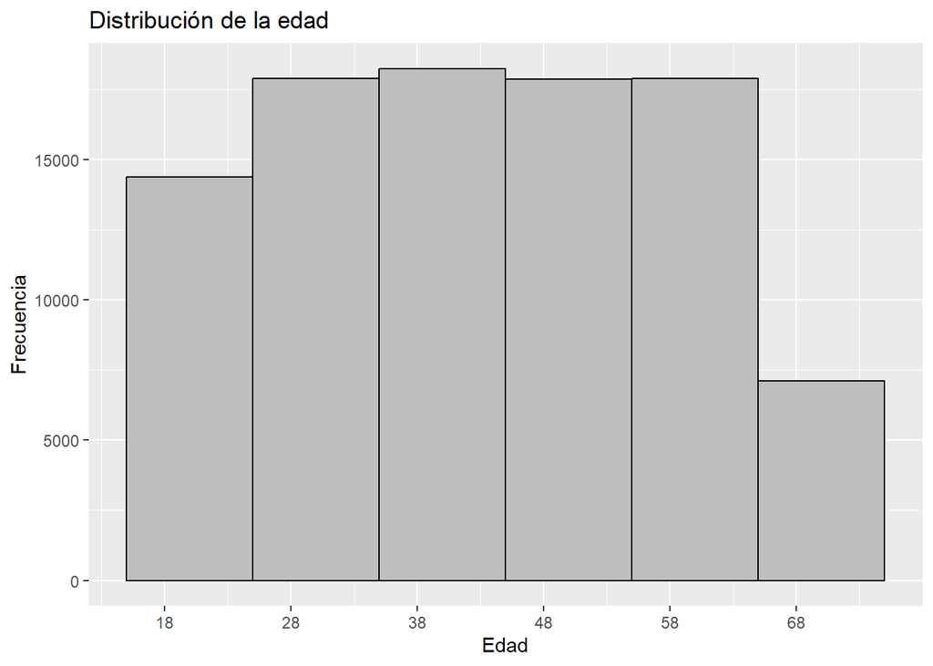

[output not shown]

[output cut: 240 more lines]

[output not shown]

En cuanto a las cantidades de compras, según el segmento de datos, la mayoría de objetos comprados fueron entre 1 y 2, aunque no presentan mucha diferencia con las demás opciones. Ahora bien, la distribución es relativamente homogénea, no está demasiado sesgada hacia la izquieda, aunque estos datos sí ostentaron mayor cantidad de datos.

```
[1] "Gráfico de cantidades compradas"
```

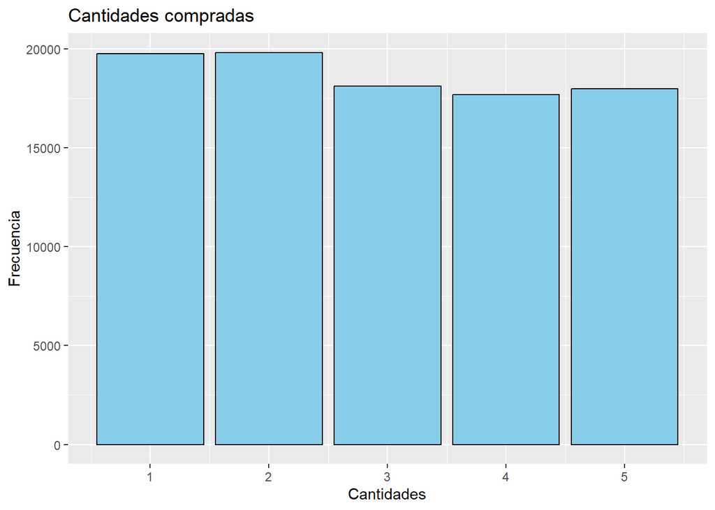

```
[1] "Gráfico de la distribución de precios"
```

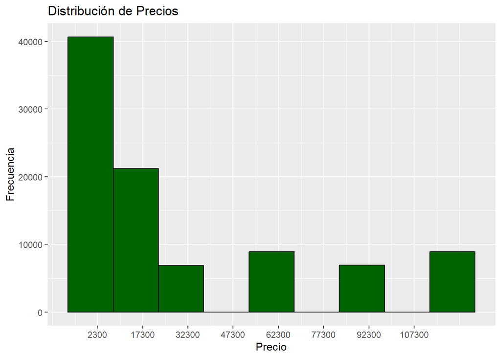

[output not shown]

[output cut: 240 more lines]

[output not shown]

Se puede observar que el método de pago preferido por los clientes es efectivo, cuatro de cada diez personas prefirieron usar este medio de pago. Las tarjetas débido son las que menos forma de pago tienen, con solo dos de cada diez casos. Seguramente, por las ventajas que dan las entidades bancarias, las tarjetas crédito se ha popularizado como forma de pago.

```
[1] "Gráfico de método de pago"
```

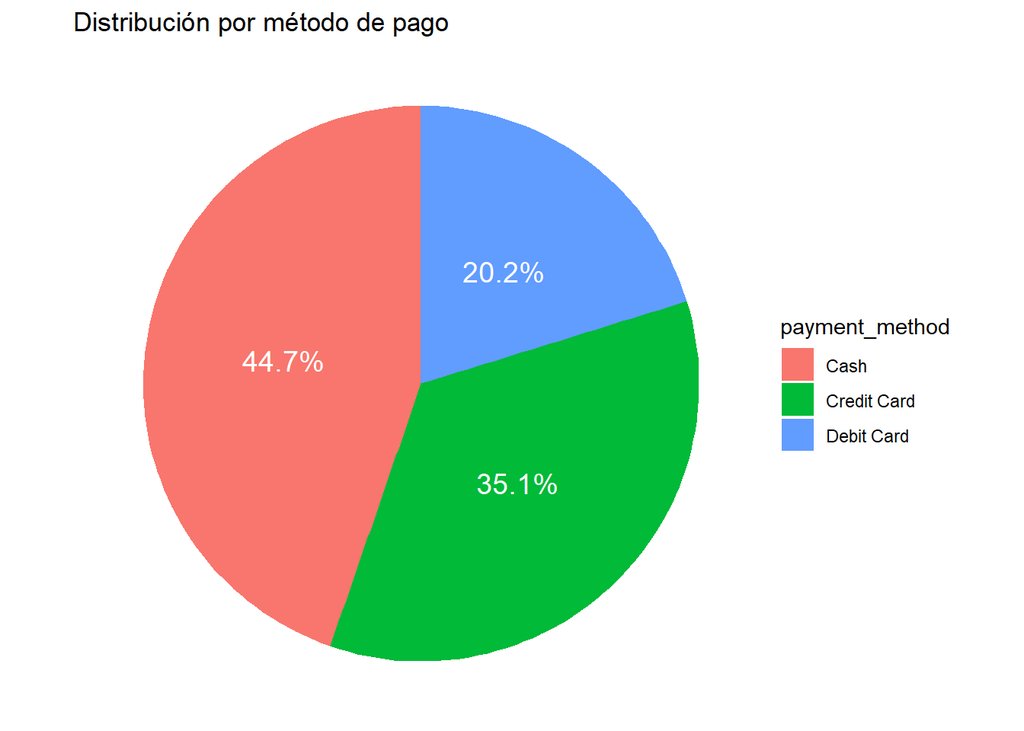

[output not shown]

[output not shown]

```
[1] "Tabla de resumen de las variables"
```

|  | invoice_no | customer_id | gender | age | category | quantity | price | payment_method | invoice_date | shopping_mall | atipico |
| --- | --- | --- | --- | --- | --- | --- | --- | --- | --- | --- | --- |
|  | Length:93389 | Length:93389 | Length:93389 | Min. :18.00 | Length:93389 | Min. :1.000 | Min. : 1 | Length:93389 | Min. :2021-01-01 | Length:93389 | Min. :0 |
|  | Class :character | Class :character | Class :character | 1st Qu.:30.00 | Class :character | 1st Qu.:2.000 | 1st Qu.: 2346 | Class :character | 1st Qu.:2021-07-19 | Class :character | 1st Qu.:0 |
|  | Mode :character | Mode :character | Mode :character | Median :43.00 | Mode :character | Median :3.000 | Median : 10752 | Mode :character | Median :2022-02-04 | Mode :character | Median :0 |
|  | NA | NA | NA | Mean :43.44 | NA | Mean :2.939 | Mean : 30078 | NA | Mean :2022-02-04 | NA | Mean :0 |
|  | NA | NA | NA | 3rd Qu.:56.00 | NA | 3rd Qu.:4.000 | 3rd Qu.: 60016 | NA | 3rd Qu.:2022-08-22 | NA | 3rd Qu.:0 |
|  | NA | NA | NA | Max. :69.00 | NA | Max. :5.000 | Max. :120034 | NA | Max. :2023-03-08 | NA | Max. :0 |

De igual manera, se puede ver que en la variable atipico no hay datos, puesto que previamente se apartaron en los pasos previos en el presente análisis

## Cruce de variables

A continuación se dejan las gráficas con las cuale se puede realizar un análisis bivariado. Se destaca, además, que la variable que más se ha prestado para esto ha sido la de género, la cual ayuda a observar los datos desde otra perspectiva. Igualmente destabale es el hecho de que el uso de diagramas de barras facilita la lectura de los datos.

```
[1] "Gráfico de clientes por sexo"
```

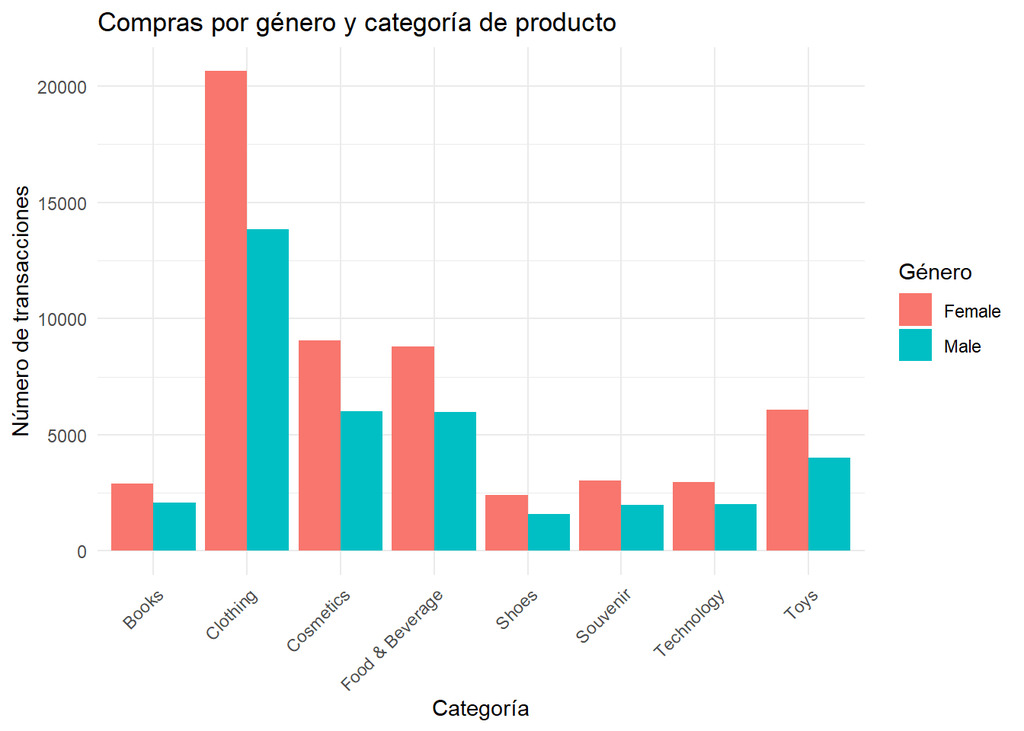

```
[1] "Gráfico de ventas por centro comercial"
```

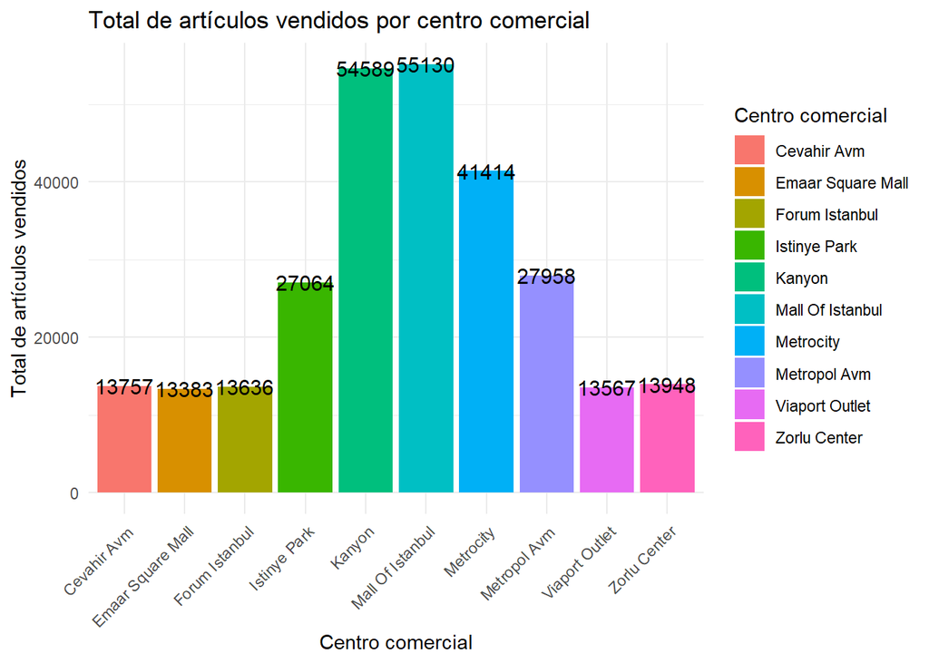

```
[1] "Gráfico de categorías por centro comercial"
```

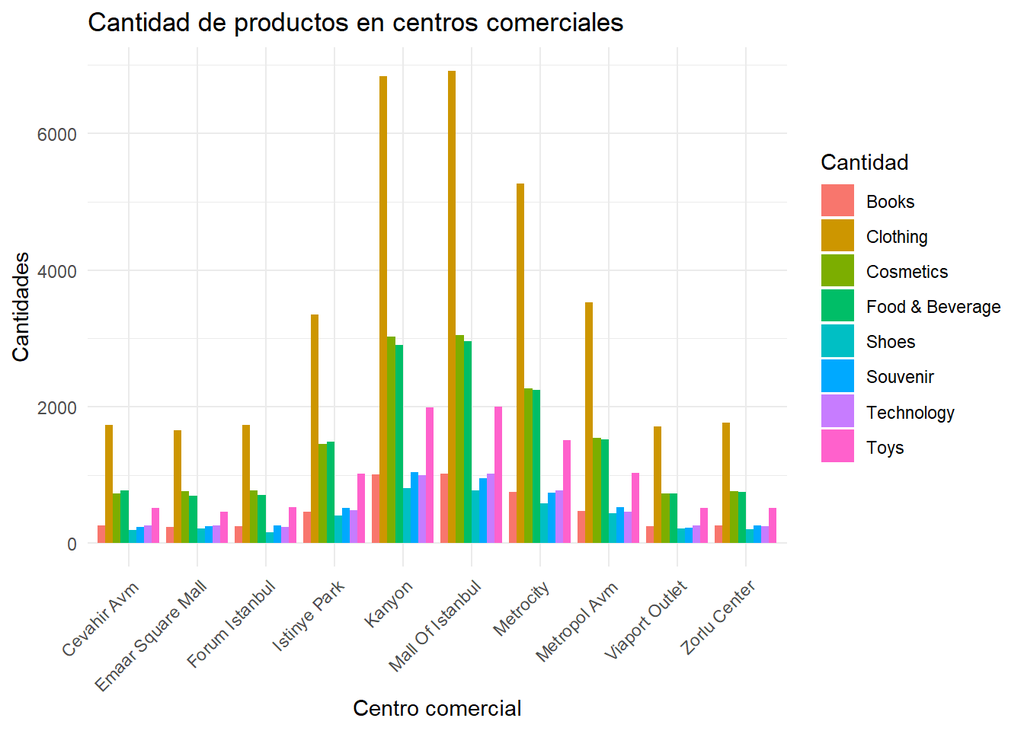

```
[1] "Gráfico de dispersión con regresión lineal"
```

[figure not shown]

```
[1] "Gráfico de centro categorías vendidas por centro comercial"
```

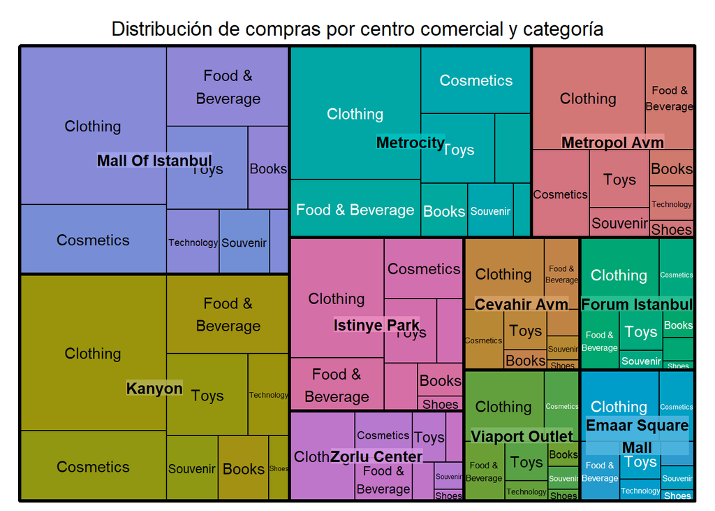

[output not shown]

[output not shown]

# *Paso 9*: Selección de resultados para el informe

Los gráficos escogidos en el presente análisis, que resumen los hallazgos del mismo y sirven para el informe que se debe presentar son los siguientes:

```
[1] "Gráfico por género"
```

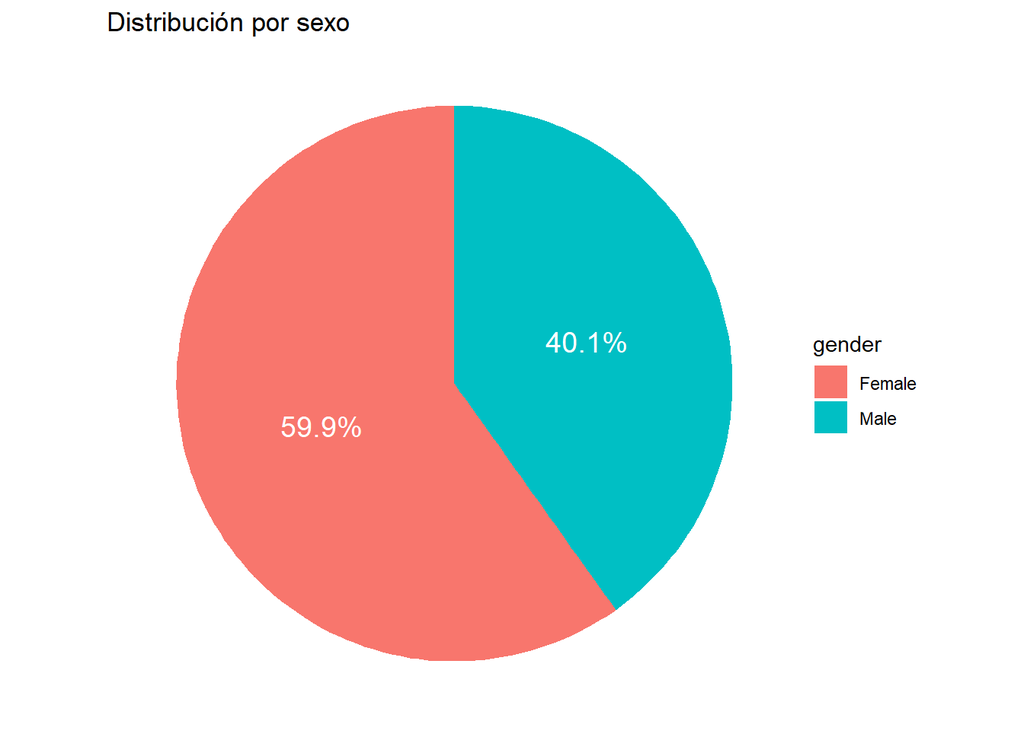

```
[1] "Gráfico por edad"
```

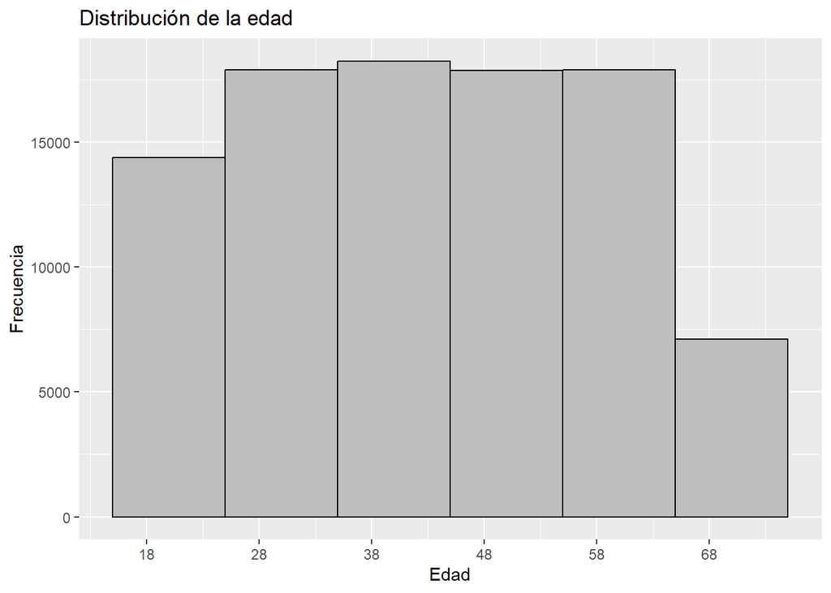

[output not shown]

[output cut: 240 more lines]

[output not shown]

```
[1] "Método de pago"
```

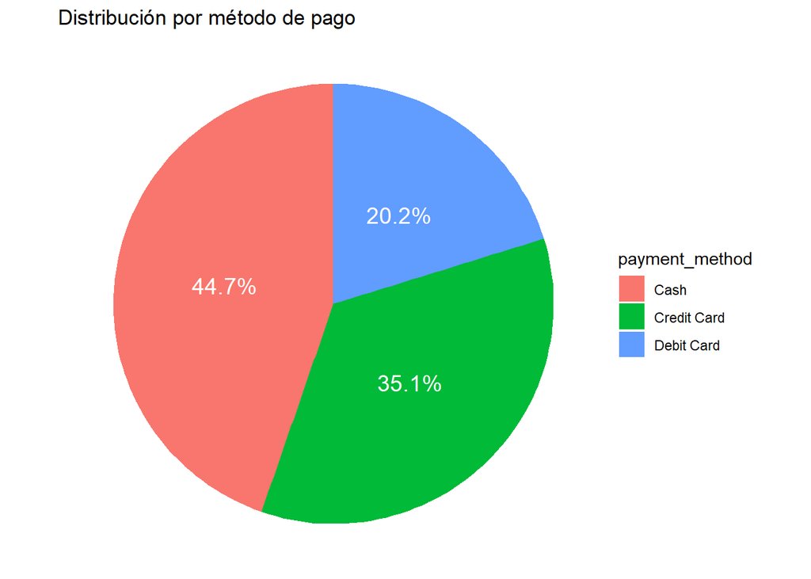

```
[1] "Compras por género"
```

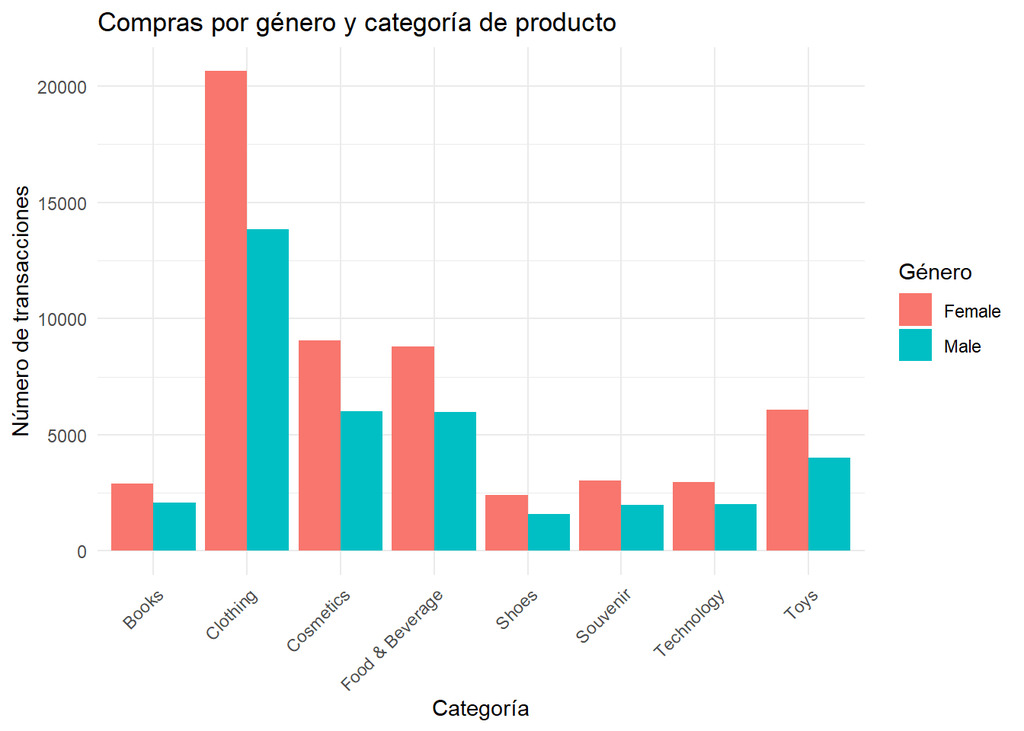

```
[1] "Ventas en centros comerciales"
```

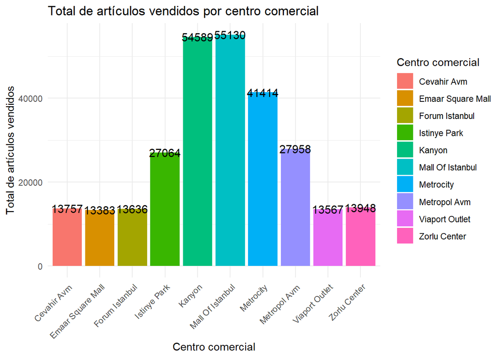

```
[1] "Ventas en centro comercial por categoría"
```

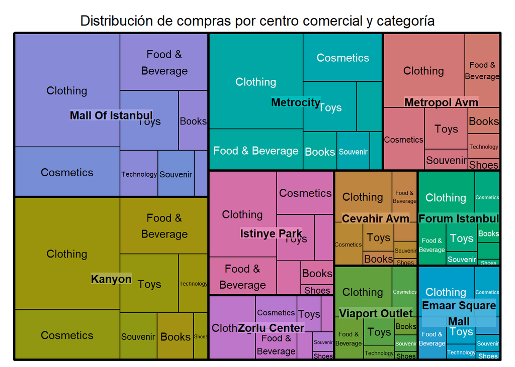

[output not shown]

[output not shown]

# *Paso 10*: Explicación de patrones y tendencias

En el presente informe se exponen las tendencias encontradas luego de realizar un análisis exploratorio a los datos dados. Dentro de este se pueden ver las ventas realizadas en distintos centros comerciales en Estambul.

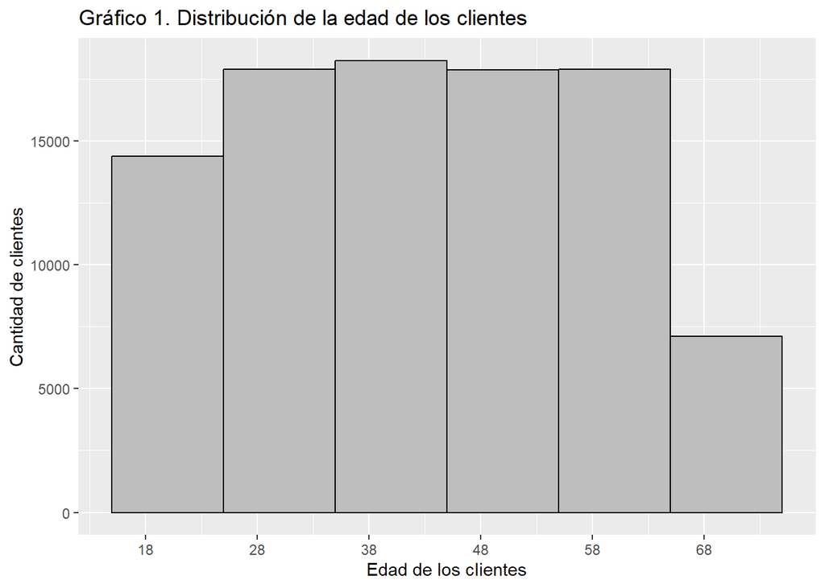

[output not shown]

[output cut: 240 more lines]

[output not shown]

Los datos anteriores se desagregan en hombres y mujeres. Estos dos grupos poblacionales se dividen así: cerca del 60 % son mujeres y el 40 % son hombres. Esto podría explicar las categorías de productos que más fueron vendidos en el periodo analizado. Además, el saber que la población es mayoritariamente femenina puede abrir una ventana de oportunidad para fortalcer productos que sean atractivos para este segemento poblacional y también para retener a los hombres y, eventualmente, atraer más mediante estrategias.

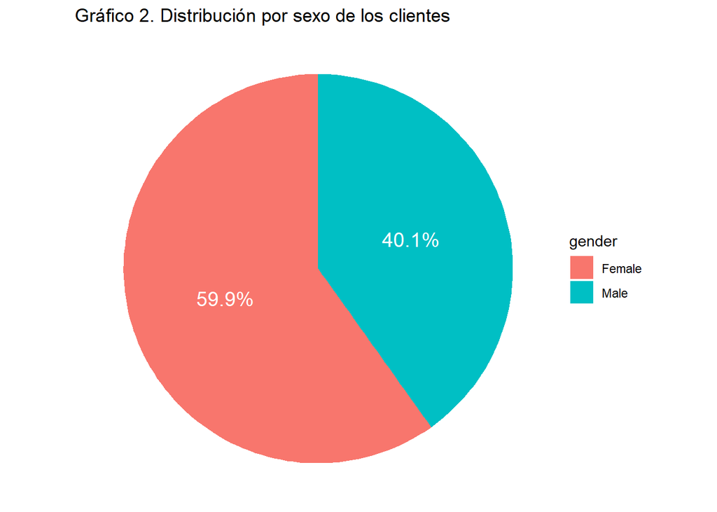

La forma de pago que prefieren los clientes ha sido efectivo, seguido del uso de tarjeta de crédito. Esto puede ser el resultado de la bancarización de las personas o de la confianza de medios electrónicos de pago o distintos al tradicional intercambio de moneda por producto. Además, el uso de tarjetas crédito sobre débito también puede ser el resultado de ofertas o beneficios que otorguen los bancos a los usuarios por el uso de estos medios, sumado a motivos de seguridad.

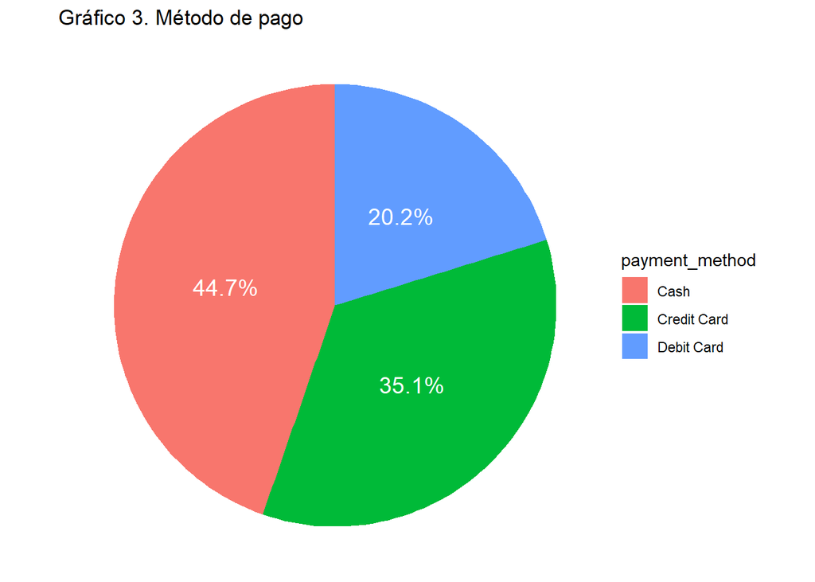

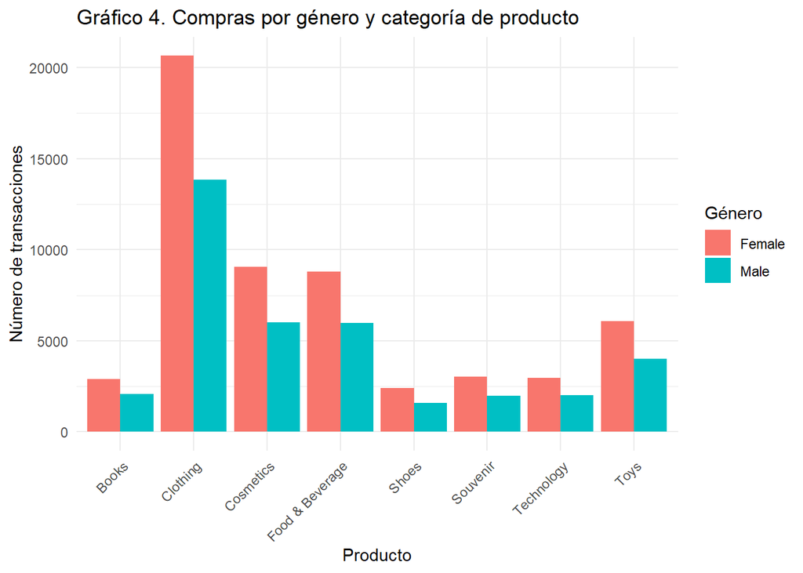

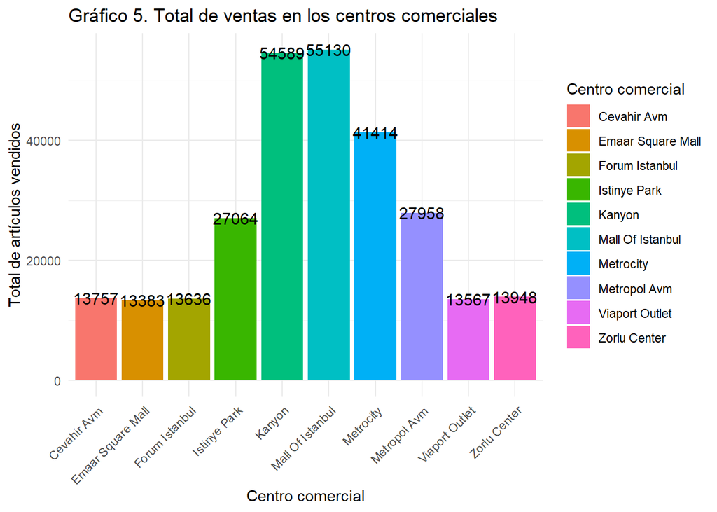

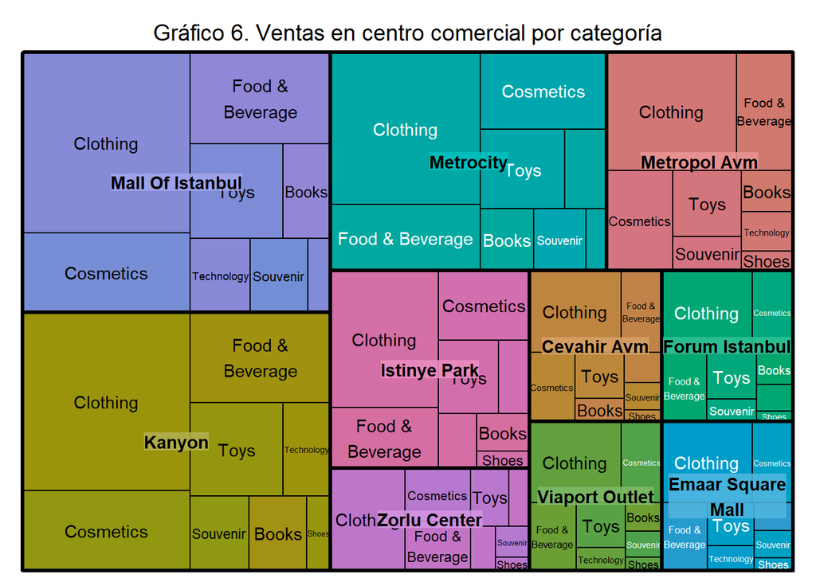

Se puede evidenciar como tendencia que no el nivel de ventas presentadas en el periodo analizado es relativamente normal, salvo con periodos donde es más bajo. Sin embargo, a simple vista no parece haber periodos de tiempo en el que alguna festividad o episodio similar explique un comportamiento extraño. Por consiguiente, se puede determinar que en este tipo de sucesos son sostenibles en el tiempo.

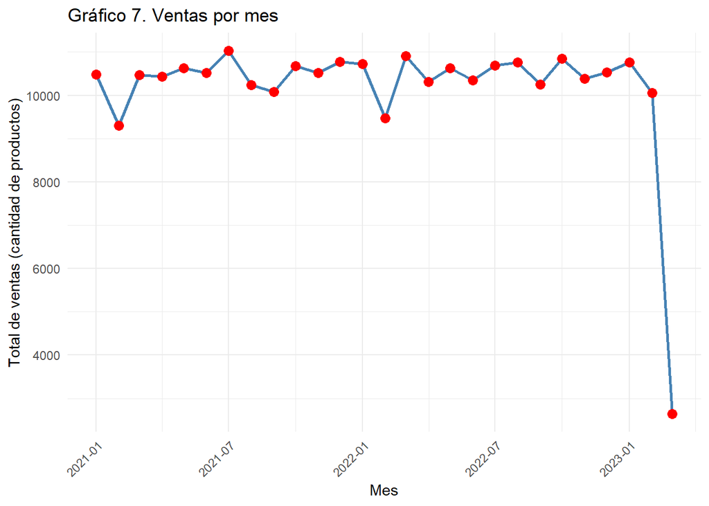

Estas ventas por año demuestran, como se ha mencionado en otros apartes del informe, que las muejes son significan la mayor cantidad de clientes y de ventas en cada año estudiado, con notable diferencia en comparación con los hombres. La diferencia con el último periodo es el momento en que se tomaron los datos. Sin embargo, dada la gráfica anterior, se puede concluir que hay un comportamiento normal en estos datos.

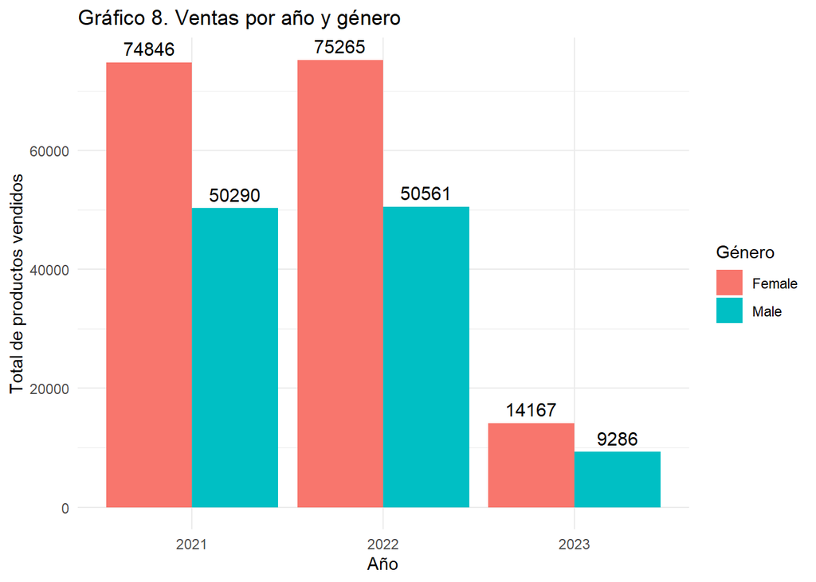

# *Conclusión*

Finalmente, se pueden concluir varias cosas de este set de datos. Por un lado, la mayoría de clientes son mujeres y lo que más se vende son prendas de vestir, ropa, seguido de cosméticos y comida. Esto, a priori, representa, o puede hacerlo, una correlación entre género y productos adquiridos en algunos ítems. En segundo lugar, los clientes son jóvenes, la mayoría tienen entre 18 y 48 años; la edad promedio es de 43 años de edad.

En todos los centros comerciales se ha visto una relación similar: la ropa es el ítem que más se vende y los zapatos lo que menos. Con estos datos se pueden destinar distintas campañas a estos segmentos poblacionales, por edad o por sexo.

Las mujeres son el segmento poblacional de clientes que mayor cantidad de compras realizó a lo largo de cada periodo estudiado y presentan diferencias con los hombres.

#### *Bibliografía*

Muñoz, J y Álvarez, E. (2009). Métodos de imputación para el tratamiento de datos faltantes: Aplicación mediante R/Splus. Revista de Métodos Cuantitativos para la Economía y la Empresa. (7), pp. 3-10. Disponible en: www.upo.es/revistas/index.php/RevMetCuant/article/view/2120/1689